# Equilibrium andalusite <--> kyanite

Thermodynamics of **kyanite** is here evaluated from frequencies and static energies evaluated *ab initio*, and processed within the framework offered by the *Quasi-Harmonic approximation* (QHA)

The modified Kieffer model is used to estimate the contribution of the acoustic modes to the Helmholtz free energy

The following command is a directive issued in order to show plots directly in the current notebook, instead of being done in a separate windows

```python
%matplotlib inline
```

In the following cell, the program is loaded; the input file is shown and the Kieffer model is applied to estimate the free energy contribution from the acoustic modes, in a given temperature range. The $F_{acoustic}(T)$ function, in *numerical* form, is stored in a stack from which values of $F$, at any temperature in the range, are recovered by numerical interpolation of the stored values by the method *get_value* of the *kieffer* class

```python
%run bm3_thermal_2.py
```

```
This is BMx-QM program, version 2.4.0 - 18/02/2021
Run time:  2021-05-15 19:25:58.725099

File quick_start.txt found in the master folder
Input files in 'kyanite' folder

Input file

TITLE
Kyanite
STATIC
static.txt
VOLUME
volumes.txt
FREQ
frequencies.txt
EXP
experimental.txt
FITVOL
POLY
283. 302. 16 2
FU
4 8
SET
0 1 2 3 4 5 6 7
CP
0. 1. -2. -0.5 -1. -3.
ALPHA
0. -1. -2. -0.5
KIEFFER
200. 300. 300.
END

-------- End of input file -------


Warning ** Volume and frequencies lists have been sorted
           indexing:  [7 6 5 4 3 2 1 0]


Static BM3 EoS

Bulk Modulus: 184.19 (0.03) GPa
Kp:             3.95 (0.01)
V0:           298.0788 (0.00) A^3
E0:            -4.59916109e+03 (3.01e-07) hartree


Kieffer model for the acoustic branches activated
```

The *info.show* command displays various parameters set in the *input.txt* file

```python
info.show()
```

```
Kyanite

Current settings and results

Static data            ** min, max volumes: 280.1477, 303.9919; points: 11
Frequency volume range ** min, max volumes: 283.6984, 301.4423; points: 8
Selected freq. sets    ** min, max volumes: 283.6984, 301.4423; points: 8
Frequency sets:           [0, 1, 2, 3, 4, 5, 6, 7]

Fit of frequencies     ** type: poly, degree: 2
                          min, max volumes: 283.0000, 302.0000; points 16

** Static EoS (BM3) **
K0: 184.19 GPa, Kp: 3.95, V0: 298.0788 A^3

No zone center excluded modes
No off center excluded modes

Kieffer model on; frequencies 200.00 300.00 300.00 cm^-1

**** Volume driver for volume_dir function ****
Delta: 2.0; degree:  2; left: 2.0; right: 2.0, Kp_fix: True; t_max: 500.00
EoS shift: 0.0; Quad_shrink:  4; T_dump: 0.0; Dump fact.: 1.0, T_last  0.0
```

A 3^rd order Birch-Murnaghan EoS (BM3) is computed at 300K; this is done by fitting a volume integrated form of the EoS to the $F(V)$ numerical values.

```
 ** BM3 fit **

EoS at the temperature of 300.00 K

Bulk Modulus: 176.51   (0.01) GPa
Kp:             4.00   (0.00)
V0:           301.4421 (0.000) A^3

Fix status: False
Fit of frequencies is active
Polynomial fit: degree  2
Volume range: 283.00 - 302.00, points=16
```

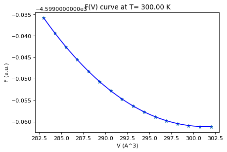

```
Volume-Pressure list at 300.00 K

 283.000   12.64
 284.267   11.64
 285.533   10.67
 286.800    9.71
 288.067    8.77
 289.333    7.86
 290.600    6.96
 291.867    6.08
 293.133    5.22
 294.400    4.37
 295.667    3.55
 296.933    2.74
 298.200    1.95
 299.467    1.18
 300.733    0.42
 302.000   -0.33
```

```python
eos_temp(300)
```

The same result is obtained by fitting the BM3 EoS to the $P(V)$ set of values at 300K; pressures $P$ at each volume are computed as derivatives of $F$ with respect to $V$, at constant temperature:

```
BM3 EoS from P(V) fit

K0:    176.50   (0.01) GPa
Kp:      4.00   (0.00)
V0:  301.4423   (0.00) A^3
```

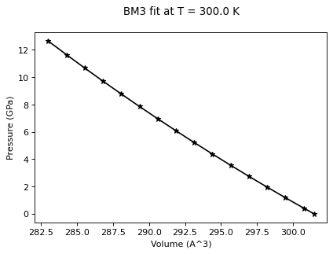

```python
bulk_dir(300)
```

A comparison of computed $C_P$ and $S$ with available experimental data is possible; $K_p$ is fixed at the value estimated at 300K

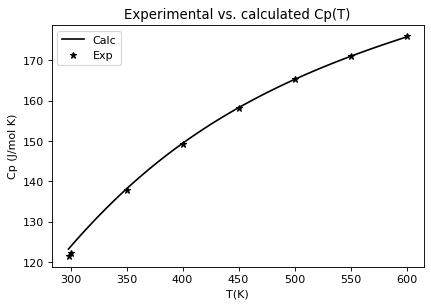

```python
set_fix(4.00)
compare_exp()
```

In the following, the equilibrium *kyanite <--> andalusite* will be analysed. To begin with, the equilibrium curve in the *P/T* space is calculated by using the Holland & Powell (H&P) thermodynamics data. Such data for kyanite are shown by the method *info* of the *ky* instance of the class *mineral*:

```python
ky.info()
```

```
Mineral: kyanite

K0: 159.00 GPa, Kp: 4.00, dK0/dT: -0.0238 GPa/K, V0: 4.4140 J/bar
G0: -2442541.00 J/mol, S0:  83.50 J/mol K

EoS type: m
Cp coefficients and powers:
+2.7940e+02  +0.0
-7.1240e-03  +1.0
-2.0556e+06  -2.0
-2.2894e+03  -0.5

Alpha coefficients and powers:
+4.0400e-05  +0.0
-4.0400e-04  -0.5
```

The equilibrium curve is computed by the command *equilib* in the 500 - 700K temperature range (12 points)

```
 T (K)  P (GPa)  DH(J/mol)  DS (J/mol K)  DV (J/bar)  Slope (bar/K)
500.0    0.04   -4678.303      -9.357       -0.742       12.61
518.2    0.06   -4841.963      -9.344       -0.742       12.59
536.4    0.08   -5004.423      -9.330       -0.742       12.57
554.5    0.10   -5165.743      -9.315       -0.742       12.55
572.7    0.13   -5325.980      -9.299       -0.742       12.53
590.9    0.15   -5485.183      -9.283       -0.742       12.50
609.1    0.17   -5643.400      -9.265       -0.742       12.48
627.3    0.20   -5800.673      -9.247       -0.743       12.45
645.5    0.22   -5957.041      -9.229       -0.743       12.43
663.6    0.24   -6112.542      -9.211       -0.743       12.40
681.8    0.26   -6267.208      -9.192       -0.743       12.37
700.0    0.29   -6421.072      -9.173       -0.743       12.35
```

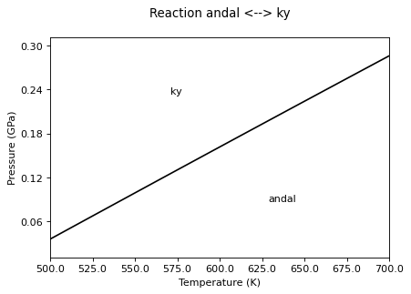

```
Average Clapeyron Slope (from Delta S/Delta V):  12.49 bar/K
Clapeyron slope (from a linear fit of the P/T curve):  12.49 bar/K
```

```python
equilib(500, 700, 12, prod=['ky',1], rea=['andal',1])
```

Now, thermodynamics data for kyanite are computed from quantum-mechanical (QM) calculations. These regard:

1. bulk modulus and its pressure derivative;
2. thermal expansion as a function of $T$;
3. specific heat (at constant pressure) as function of $T$;
4. entropy at the reference state (T=298.15 K, P=1 bar)

The volume at the reference state is the experimental one: as it is well known, quantum-mechanical calculations generally overestimate cell volumes; this fact leads to an overestimation of the $PV$ contribution to the Gibbs free energy ($G=F+PV$) which generally becomes significant at high pressures.

The $G$ free energy in the reference ($G_0$) is also from the H&P database: the $G$ energy computed at the QM level is some *absolute* energy of the mineral phase, whereas the corresponding quantity from the H&P database is the energy of formation from the elements. In order to properly fix the *zero* of the energy scale (that is, to put both kyanite and andalusite on the same energy scale), the $G_0$ must be properly set.

All of such calculations, together with the loading of such quantities in the instance *ky* of the *mineral* class, are performed by the *upload_mineral* command:

```
 ** BM3 fit **

EoS at the temperature of 298.15 K

Bulk Modulus: 176.54   (0.01) GPa
Kp:             4.00   (0.00)
V0:           301.4329 (0.000) A^3

Fix status: False
Fit of frequencies is active
Polynomial fit: degree  2
Volume range: 283.00 - 302.00, points=16

Results from the fit (from high to low order)
[-1.87e-02  1.82e+02]
```

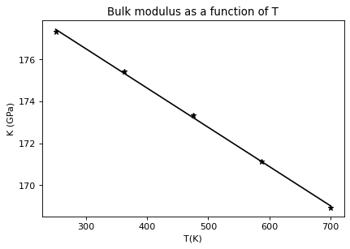

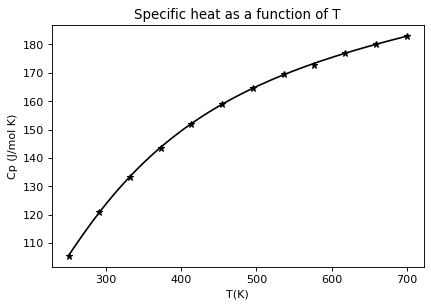

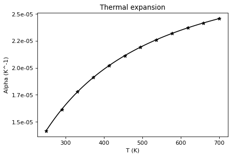

```python
upload_mineral(250,700,mqm='ky', volc=True)
```

Now, *ky.info* will show the new data stored in the database, for kyanite:

```python
ky.info()
```

```
Mineral: kyanite

K0: 176.54 GPa, Kp: 4.00, dK0/dT: -0.0187 GPa/K, V0: 4.4140 J/bar
G0: -2442541.00 J/mol, S0:  83.25 J/mol K

EoS type: bm
Cp coefficients and powers:
-2.9986e+02  +0.0
+1.2169e-01  +1.0
+1.2437e+07  -2.0
+2.0340e+04  -0.5
-2.7762e+05  -1.0
+1.0000e+00  -3.0

Alpha coefficients and powers:
+3.0117e-05  +0.0
-6.5918e-03  -1.0
+3.1400e-01  -2.0
+8.5304e-05  -0.5
```

```
 T (K)  P (GPa)  DH(J/mol)  DS (J/mol K)  DV (J/bar)  Slope (bar/K)
500.0    0.04   -4685.225      -9.370       -0.742       12.63
518.2    0.06   -4851.442      -9.362       -0.742       12.61
536.4    0.08   -5018.134      -9.356       -0.742       12.61
554.5    0.11   -5185.431      -9.351       -0.742       12.60
572.7    0.13   -5353.409      -9.347       -0.742       12.59
590.9    0.15   -5522.089      -9.345       -0.742       12.59
609.1    0.18   -5691.441      -9.344       -0.742       12.59
627.3    0.20   -5861.383      -9.344       -0.742       12.59
645.5    0.22   -6031.784      -9.345       -0.742       12.59
663.6    0.24   -6202.473      -9.346       -0.743       12.59
681.8    0.27   -6373.234      -9.347       -0.743       12.59
700.0    0.29   -6543.817      -9.348       -0.743       12.59
```

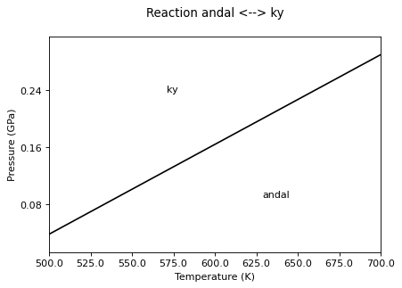

```
Average Clapeyron Slope (from Delta S/Delta V):  12.60 bar/K
Clapeyron slope (from a linear fit of the P/T curve):  12.59 bar/K
```

```python
equilib(500, 700, 12, prod=['ky',1], rea=['andal',1])
```

The impact of the contribution form acoustic modes for the present case is well shown by switching off the Kieffer model and by repeating the computation:

```
Kieffer correction off

 ** BM3 fit **

EoS at the temperature of 298.15 K

Bulk Modulus: 176.54   (0.01) GPa
Kp:             4.00   (0.00)
V0:           301.4329 (0.000) A^3

Fix status: False
Fit of frequencies is active
Polynomial fit: degree  2
Volume range: 283.00 - 302.00, points=16

Results from the fit (from high to low order)
[-1.87e-02  1.82e+02]
```

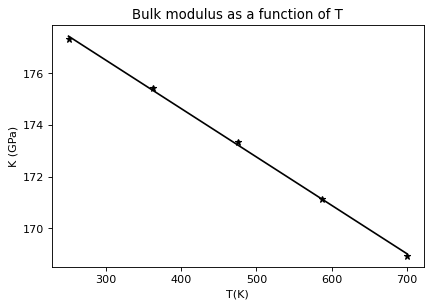

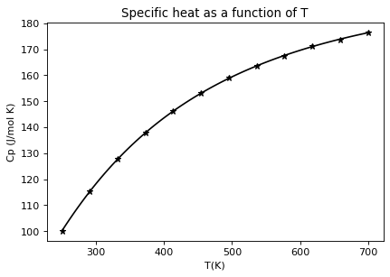

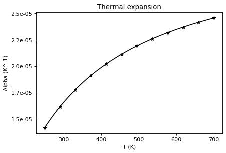

```
Mineral: kyanite

K0: 176.54 GPa, Kp: 4.00, dK0/dT: -0.0187 GPa/K, V0: 4.4140 J/bar
G0: -2442541.00 J/mol, S0:  77.23 J/mol K

EoS type: bm
Cp coefficients and powers:
+1.7667e+02  +0.0
-1.1546e-02  +1.0
+4.8148e+06  -2.0
+3.4013e+03  -0.5
-9.1446e+04  -1.0
+1.0000e+00  -3.0

Alpha coefficients and powers:
+3.0620e-05  +0.0
-6.2078e-03  -1.0
+2.9092e-01  -2.0
+5.8886e-05  -0.5

 T (K)  P (GPa)  DH(J/mol)  DS (J/mol K)  DV (J/bar)  Slope (bar/K)
500.0    0.25    -9175.306    -18.351       -0.739       24.83
518.2    0.29    -9608.680    -18.543       -0.739       25.10
536.4    0.34   -10045.599    -18.729       -0.739       25.36
554.5    0.38   -10486.302    -18.910       -0.738       25.61
572.7    0.43   -10931.050    -19.086       -0.738       25.86
590.9    0.48   -11380.109    -19.259       -0.738       26.11
609.1    0.53   -11833.751    -19.429       -0.737       26.35
627.3    0.57   -12292.242    -19.596       -0.737       26.59
645.5    0.62   -12755.847    -19.763       -0.737       26.83
663.6    0.67   -13224.821    -19.928       -0.736       27.06
681.8    0.72   -13699.412    -20.092       -0.736       27.30
700.0    0.77   -14179.858    -20.257       -0.736       27.54
```

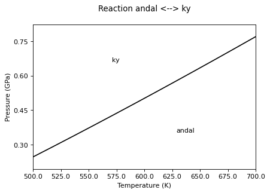

```
Average Clapeyron Slope (from Delta S/Delta V):  26.21 bar/K
Clapeyron slope (from a linear fit of the P/T curve):  26.22 bar/K
```

```python
kieffer.off()
upload_mineral(250, 700, mqm='ky', volc=True)
ky.info()
equilib(500, 700, 12, prod=['ky',1], rea=['andal',1])
```

Indeed, the equilibrium curve is shifted at significantly higher pressures and the Clapeyron slope significantly increases.

The frequencies used in the Kieffer model can be set by the *freq* method of the *kieffer* class (or the input file, under the KIEFFER keyword):

```
Kieffer correction on

 ** BM3 fit **

EoS at the temperature of 298.15 K

Bulk Modulus: 176.54   (0.01) GPa
Kp:             4.00   (0.00)
V0:           301.4329 (0.000) A^3

Fix status: False
Fit of frequencies is active
Polynomial fit: degree  2
Volume range: 283.00 - 302.00, points=16

Results from the fit (from high to low order)
[-1.87e-02  1.82e+02]
```

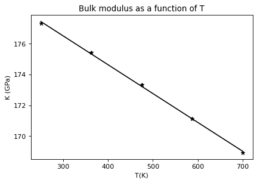

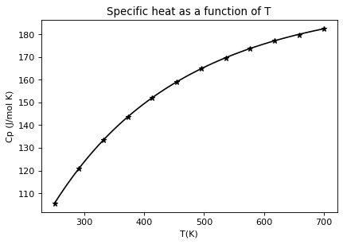

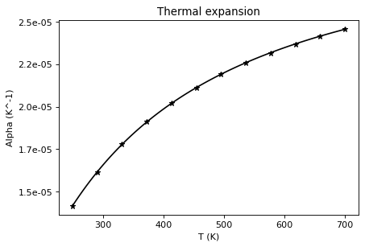

```
Mineral: kyanite

K0: 176.54 GPa, Kp: 4.00, dK0/dT: -0.0187 GPa/K, V0: 4.4140 J/bar
G0: -2442541.00 J/mol, S0:  83.59 J/mol K

EoS type: bm
Cp coefficients and powers:
+2.7928e+02  +0.0
-3.7895e-02  +1.0
+3.2153e+06  -2.0
+6.2067e+00  -0.5
-5.4019e+04  -1.0
+1.0000e+00  -3.0

Alpha coefficients and powers:
+3.0494e-05  +0.0
-6.2966e-03  -1.0
+2.9597e-01  -2.0
+6.5213e-05  -0.5

 T (K)  P (GPa)  DH(J/mol)  DS (J/mol K)  DV (J/bar)  Slope (bar/K)
500.0    0.03   -4502.591      -9.005       -0.742       12.13
518.2    0.05   -4656.308      -8.986       -0.742       12.11
536.4    0.07   -4809.587      -8.967       -0.742       12.08
554.5    0.09   -4962.872      -8.949       -0.742       12.05
572.7    0.12   -5116.624      -8.934       -0.742       12.03
590.9    0.14   -5271.317      -8.921       -0.743       12.01
609.1    0.16   -5427.427      -8.911       -0.743       12.00
627.3    0.18   -5585.429      -8.904       -0.743       11.99
645.5    0.20   -5745.791      -8.902       -0.743       11.98
663.6    0.23   -5908.977      -8.904       -0.743       11.99
681.8    0.25   -6075.437      -8.911       -0.743       11.99
700.0    0.27   -6245.614      -8.922       -0.743       12.01
```

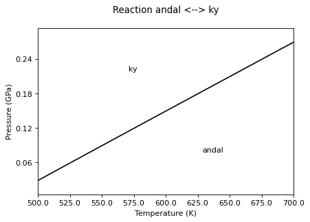

```
Average Clapeyron Slope (from Delta S/Delta V):  12.03 bar/K
Clapeyron slope (from a linear fit of the P/T curve):  12.02 bar/K
```

```python
kieffer.on()
kieffer.freq(200, 250, 300)
upload_mineral(250, 700, mqm='ky',volc=True)
ky.info()
equilib(500, 700, 12, prod=['ky',1], rea=['andal',1])
```